# Лабораторная работа №4 Способы подготовки исходных данных

Анализ данных

Быков Александр

2026-02-22

# Введение

В данной лабораторной работе рассматриваются различные способы подготовки исходных данных в языке R. Будут изучены методы очистки данных от пропущенных значений (NA), обработки выбросов, удаления дублируемых записей, а также методы заполнения пропусков с помощью статистических моделей.

# Задание 1

**Задание:** Сформируйте свой собственный датасет с помощью функции c (конкатенация), в котором содержатся числовые данные и NA значения.

```r
# Создаем числовой вектор с NA значениями
x <- c(7, 2, NA, 8, NA, 9, 1, 15, NA, 12, 4, NA, 6)

# Выводим созданный датасет
print("Созданный датасет с NA значениями:")
```

```
## [1] "Созданный датасет с NA значениями:"
```

```r
print(x)
```

```
##  [1]  7  2 NA  8 NA  9  1 15 NA 12  4 NA  6
```

```r
# Проверяем количество NA значений
cat("\nКоличество NA значений:", sum(is.na(x)), "\n")
```

```
##
## Количество NA значений: 4
```

```r
cat("Общее количество элементов:", length(x), "\n")
```

```
## Общее количество элементов: 13
```

# Задание 2

**Задание:** Проведите очистку данных с использованием функции `is.na()` и выведите “чистый” датасет.

```r
# Исходный датасет
x <- c(7, 2, NA, 8, NA, 9, 1, 15, NA, 12, 4, NA, 6)
print("Исходный датасет:")
```

```
## [1] "Исходный датасет:"
```

```r
print(x)
```

```
##  [1]  7  2 NA  8 NA  9  1 15 NA 12  4 NA  6
```

```r
# Определяем позиции NA значений
bad <- is.na(x)
cat("\nЛогический вектор is.na(x) - TRUE означает NA:\n")
```

```
##
## Логический вектор is.na(x) - TRUE означает NA:
```

```r
print(bad)
```

```
##  [1] FALSE FALSE  TRUE FALSE  TRUE FALSE FALSE FALSE  TRUE FALSE FALSE  TRUE
## [13] FALSE
```

```r
# Извлекаем только "хорошие" значения (не NA)
clean_x <- x[!bad]
cat("\n'Чистый' датасет (без NA):\n")
```

```
##
## 'Чистый' датасет (без NA):
```

```r
print(clean_x)
```

```
## [1]  7  2  8  9  1 15 12  4  6
```

```r
# Альтернативный способ - использование na.omit()
clean_x_alt <- na.omit(x)
cat("\nАльтернативный способ (na.omit):\n")
```

```
##
## Альтернативный способ (na.omit):
```

```r
print(as.vector(clean_x_alt))
```

```
## [1]  7  2  8  9  1 15 12  4  6
```

# Задание 3

**Задание:** Сгенерируйте таблицу данных с числовыми и текстовыми столбцами. Очистите данные с помощью функции `complete.cases()`.

```r
# Создаем текстовый вектор с NA
x <- c("a", "b", NA, "d", NA, "f", "r", NA, "ya")

# Создаем числовой вектор с NA
y <- c(1, 2, NA, 5, NA, 7, NA, 29, 31)

# Создаем таблицу данных
df <- data.frame(text_col = x, number_col = y)
print("Исходная таблица данных:")
```

```
## [1] "Исходная таблица данных:"
```

```r
print(df)
```

```
##   text_col number_col
## 1        a          1
## 2        b          2
## 3     <NA>         NA
## 4        d          5
## 5     <NA>         NA
## 6        f          7
## 7        r         NA
## 8     <NA>         29
## 9       ya         31
```

```r
# Применяем complete.cases() для определения полных строк
good <- complete.cases(df)
cat("\nЛогический вектор complete.cases() - TRUE означает полную строку:\n")
```

```
##
## Логический вектор complete.cases() - TRUE означает полную строку:
```

```r
print(good)
```

```
## [1]  TRUE  TRUE FALSE  TRUE FALSE  TRUE FALSE FALSE  TRUE
```

```r
# Извлекаем только полные строки
df_clean <- df[good, ]
cat("\n'Чистая' таблица данных (только полные строки):\n")
```

```
##
## 'Чистая' таблица данных (только полные строки):
```

```r
print(df_clean)
```

```
##   text_col number_col
## 1        a          1
## 2        b          2
## 4        d          5
## 6        f          7
## 9       ya         31
```

```r
# Демонстрация на векторах отдельно
cat("\n--- Очистка отдельных векторов ---\n")
```

```
##
## --- Очистка отдельных векторов ---
```

```r
cat("Чистый текстовый вектор:\n")
```

```
## Чистый текстовый вектор:
```

```r
print(x[good])
```

```
## [1] "a"  "b"  "d"  "f"  "ya"
```

```r
cat("Чистый числовой вектор:\n")
```

```
## Чистый числовой вектор:
```

```r
print(y[good])
```

```
## [1]  1  2  5  7 31
```

# Задание 4

**Задание:** Проанализируйте датасет airquality с пропусками. С использованием функции `preProcess` из пакета caret, заполните пропуски предсказанными значениями (среднее, медиана).

```r
# Загружаем необходимые пакеты
library(caret)

# Загружаем датасет airquality
data(airquality)

# Просматриваем структуру данных
print("Структура датасета airquality:")
```

```
## [1] "Структура датасета airquality:"
```

```r
str(airquality)
```

```
## 'data.frame':    153 obs. of  6 variables:
##  $ Ozone  : int  41 36 12 18 NA 28 23 19 8 NA ...
##  $ Solar.R: int  190 118 149 313 NA NA 299 99 19 194 ...
##  $ Wind   : num  7.4 8 12.6 11.5 14.3 14.9 8.6 13.8 20.1 8.6 ...
##  $ Temp   : int  67 72 74 62 56 66 65 59 61 69 ...
##  $ Month  : int  5 5 5 5 5 5 5 5 5 5 ...
##  $ Day    : int  1 2 3 4 5 6 7 8 9 10 ...
```

```r
# Просматриваем первые строки с пропусками
print("\nПервые 10 строк датасета:")
```

```
## [1] "\nПервые 10 строк датасета:"
```

```r
print(head(airquality, 10))
```

```
##    Ozone Solar.R Wind Temp Month Day
## 1     41     190  7.4   67     5   1
## 2     36     118  8.0   72     5   2
## 3     12     149 12.6   74     5   3
## 4     18     313 11.5   62     5   4
## 5     NA      NA 14.3   56     5   5
## 6     28      NA 14.9   66     5   6
## 7     23     299  8.6   65     5   7
## 8     19      99 13.8   59     5   8
## 9      8      19 20.1   61     5   9
## 10    NA     194  8.6   69     5  10
```

```r
# Подсчитываем количество пропусков в каждом столбце
print("\nКоличество NA в каждом столбце:")
```

```
## [1] "\nКоличество NA в каждом столбце:"
```

```r
print(colSums(is.na(airquality)))
```

```
##   Ozone Solar.R    Wind    Temp   Month     Day
##      37       7       0       0       0       0
```

```r
# Определяем строки с пропусками
ind <- apply(airquality, 1, function(x) sum(is.na(x))) > 0
cat("\nСтроки с пропущенными значениями (до заполнения):\n")
```

```
##
## Строки с пропущенными значениями (до заполнения):
```

```r
print(airquality[ind, ])
```

```
##     Ozone Solar.R Wind Temp Month Day
## 5      NA      NA 14.3   56     5   5
## 6      28      NA 14.9   66     5   6
## 10     NA     194  8.6   69     5  10
## 11      7      NA  6.9   74     5  11
## 25     NA      66 16.6   57     5  25
## 26     NA     266 14.9   58     5  26
## 27     NA      NA  8.0   57     5  27
## 32     NA     286  8.6   78     6   1
## 33     NA     287  9.7   74     6   2
## 34     NA     242 16.1   67     6   3
## 35     NA     186  9.2   84     6   4
## 36     NA     220  8.6   85     6   5
## 37     NA     264 14.3   79     6   6
## 39     NA     273  6.9   87     6   8
```

[output cut: 28 more lines]

```r
# --- Заполнение медианой (medianImpute) ---
cat("\n Заполнение медианой (medianImpute) \n")
```

```
##
##  Заполнение медианой (medianImpute)
```

```r
# Сохраняем копию данных
airquality_median <- airquality

# Создаем препроцессор для числовых столбцов
pPmI <- preProcess(airquality_median[, c("Ozone", "Solar.R")],
  method = "medianImpute"
)

# Применяем препроцессор
airquality_median[, c("Ozone", "Solar.R")] <- predict(
  pPmI,
  airquality_median[, c("Ozone", "Solar.R")]
)

print("Строки после заполнения медианой:")
```

```
## [1] "Строки после заполнения медианой:"
```

```r
print(airquality_median[ind, ])
```

```
##     Ozone Solar.R Wind Temp Month Day
## 5    31.5     205 14.3   56     5   5
## 6    28.0     205 14.9   66     5   6
## 10   31.5     194  8.6   69     5  10
## 11    7.0     205  6.9   74     5  11
## 25   31.5      66 16.6   57     5  25
## 26   31.5     266 14.9   58     5  26
## 27   31.5     205  8.0   57     5  27
## 32   31.5     286  8.6   78     6   1
## 33   31.5     287  9.7   74     6   2
## 34   31.5     242 16.1   67     6   3
## 35   31.5     186  9.2   84     6   4
## 36   31.5     220  8.6   85     6   5
## 37   31.5     264 14.3   79     6   6
## 39   31.5     273  6.9   87     6   8
```

[output cut: 28 more lines]

```r
# Проверяем отсутствие NA
cat("\nКоличество NA после заполнения медианой:\n")
```

```
##
## Количество NA после заполнения медианой:
```

```r
print(colSums(is.na(airquality_median)))
```

```
##   Ozone Solar.R    Wind    Temp   Month     Day
##       0       0       0       0       0       0
```

```r
# Проверяем, какие значения были заполнены
cat("\nСравнение исходных и заполненных значений:\n")
```

```
##
## Сравнение исходных и заполненных значений:
```

```r
comparison <- data.frame(
  Строка = which(ind),
  Ozone_исходный = airquality[ind, "Ozone"],
  Ozone_заполненный = airquality_median[ind, "Ozone"],
  Solar_R_исходный = airquality[ind, "Solar.R"],
  Solar_R_заполненный = airquality_median[ind, "Solar.R"]
)
print(head(comparison, 10))
```

```
##    Строка Ozone_исходный Ozone_заполненный Solar_R_исходный Solar_R_заполненный
## 1       5             NA              31.5               NA                 205
## 2       6             28              28.0               NA                 205
## 3      10             NA              31.5              194                 194
## 4      11              7               7.0               NA                 205
## 5      25             NA              31.5               66                  66
## 6      26             NA              31.5              266                 266
## 7      27             NA              31.5               NA                 205
## 8      32             NA              31.5              286                 286
## 9      33             NA              31.5              287                 287
## 10     34             NA              31.5              242                 242
```

# Задание 5

**Задание:** Сгенерируйте два числовых набора данных и добавьте в них выбросы. С использованием функции `boxplot`, обнаружьте выбросы и удалить их.

```r
# Создаем два числовых набора данных с выбросами
x <- c(
  2.633213, 2.654674, 2.746650, 2.657763, 2.525229, 2.549804, 2.537088,
  1.974909, 1.838017, 1.791683, 1.782088, 1.664908, 1.689402, 1.688826,
  1.661763, 1.734322, 1.744875, 1.710471, 1.735690, 1.800677, 1.607354,
  1.896810, 2.294757
)

y <- c(
  4.358015, 4.489513, 4.560919, 4.613810, 4.599738, 4.621614, 4.633119,
  4.616862, 4.754681, 4.849953, 4.945791, 5.019631, 4.805033, 4.989170,
  5.024305, 5.065325, 4.970247, 4.998086, 5.096887, 4.977657, 4.888269,
  3.479053, 2.878145
)

# Создаем DataFrame
df_outliers <- data.frame(x = x, y = y)

print("Исходные данные:")
```

```
## [1] "Исходные данные:"
```

```r
print(df_outliers)
```

```
##           x        y
## 1  2.633213 4.358015
## 2  2.654674 4.489513
## 3  2.746650 4.560919
## 4  2.657763 4.613810
## 5  2.525229 4.599738
## 6  2.549804 4.621614
## 7  2.537088 4.633119
## 8  1.974909 4.616862
## 9  1.838017 4.754681
## 10 1.791683 4.849953
## 11 1.782088 4.945791
## 12 1.664908 5.019631
## 13 1.689402 4.805033
## 14 1.688826 4.989170
## 15 1.661763 5.024305
## 16 1.734322 5.065325
## 17 1.744875 4.970247
## 18 1.710471 4.998086
## 19 1.735690 5.096887
## 20 1.800677 4.977657
## 21 1.607354 4.888269
## 22 1.896810 3.479053
## 23 2.294757 2.878145
```

```r
# Визуализация исходных данных
par(mfrow = c(2, 2))

# Scatter plot исходных данных
plot(x, y,
  main = "Исходные данные",
  xlab = "X", ylab = "Y", pch = 19, col = "blue"
)

# Boxplot для x
boxplot(x, main = "Boxplot для X", col = "lightblue")

# Boxplot для y
boxplot(y, main = "Boxplot для Y", col = "lightgreen")

# Получаем выбросы
outliers_x <- boxplot.stats(x)$out
outliers_y <- boxplot.stats(y)$out

cat("\nВыбросы в X:\n")
```

```
##
## Выбросы в X:
```

```r
print(outliers_x)
```

```
## numeric(0)
```

```r
cat("Выбросы в Y:\n")
```

```
## Выбросы в Y:
```

```r
print(outliers_y)
```

```
## [1] 3.479053 2.878145
```

```r
# Находим индексы выбросов в Y
ind <- which(y %in% boxplot.stats(y)$out)
cat("\nИндексы выбросов в Y:\n")
```

```
##
## Индексы выбросов в Y:
```

```r
print(ind)
```

```
## [1] 22 23
```

```r
# Сохраняем координаты точек-выбросов
vybrosy <- data.frame(x = x[ind], y = y[ind])
cat("\nКоординаты точек-выбросов:\n")
```

```
##
## Координаты точек-выбросов:
```

```r
print(vybrosy)
```

```
##          x        y
## 1 1.896810 3.479053
## 2 2.294757 2.878145
```

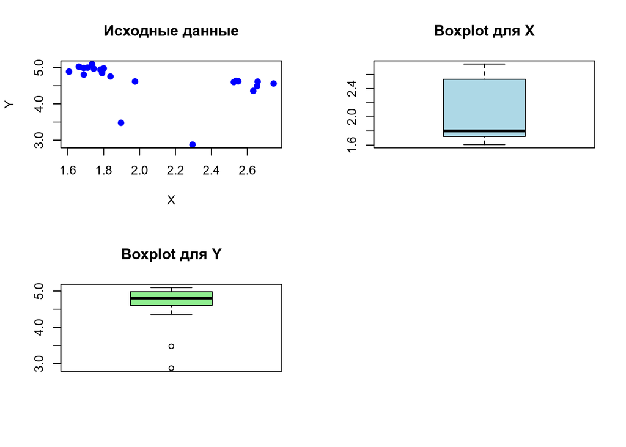

```r
# Визуализация с выделением выбросов
par(mfrow = c(1, 2))
```

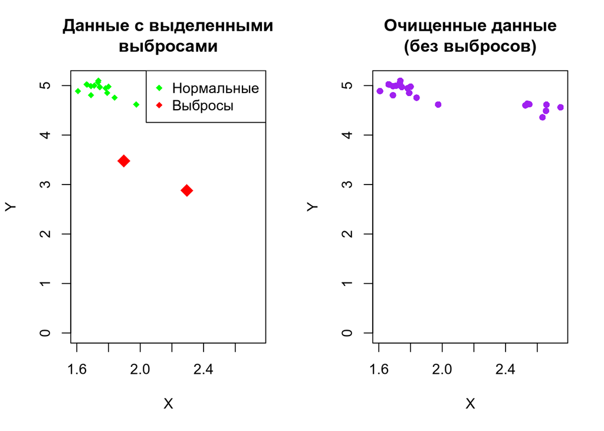

```r
plot(x, y,
  col = "green", pch = 18, ylim = c(0, max(y)),
  main = "Данные с выделенными\nвыбросами",
  xlab = "X", ylab = "Y"
)
points(vybrosy$x, vybrosy$y, col = "red", pch = 18, cex = 2)
legend("topright",
  legend = c("Нормальные", "Выбросы"),
  col = c("green", "red"), pch = 18
)

# Удаляем выбросы
x_clean <- x[-ind]
y_clean <- y[-ind]

# Визуализация очищенных данных
plot(x_clean, y_clean,
  col = "purple", pch = 16, ylim = c(0, max(y)),
  main = "Очищенные данные\n(без выбросов)",
  xlab = "X", ylab = "Y"
)
```

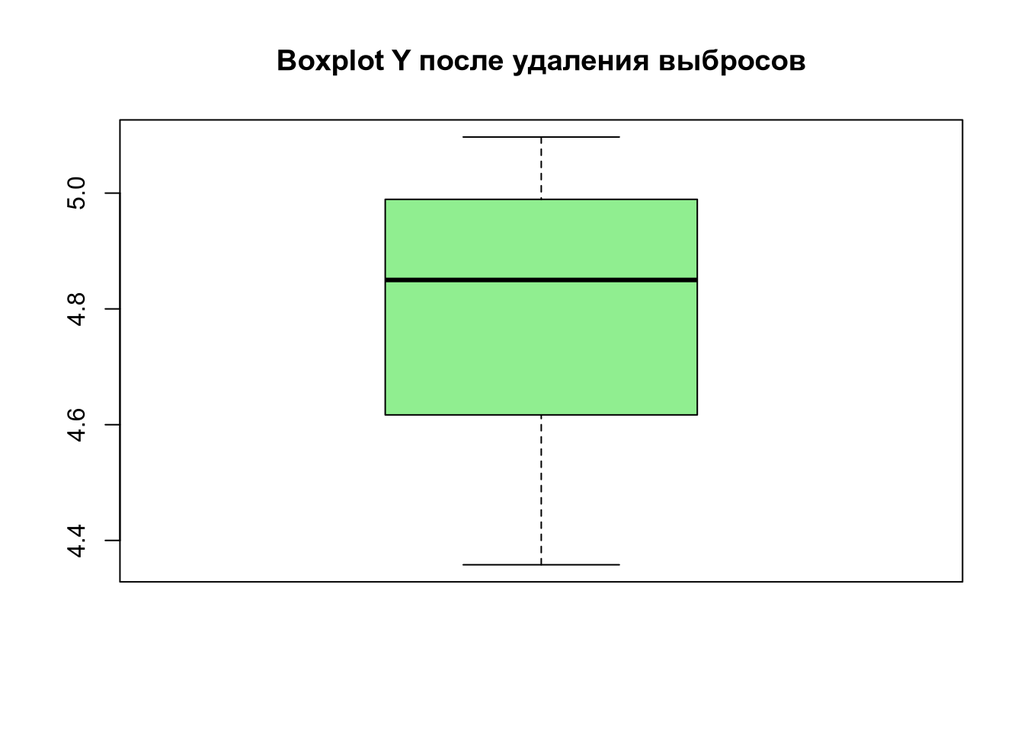

```r
par(mfrow = c(1, 1))

# Boxplot после удаления выбросов
boxplot(y_clean, main = "Boxplot Y после удаления выбросов", col = "lightgreen")
```

```r
cat("\nРазмер данных до очистки:", length(y), "\n")
```

```
##
## Размер данных до очистки: 23
```

```r
cat("Размер данных после очистки:", length(y_clean), "\n")
```

```
## Размер данных после очистки: 21
```

# Задание 6

**Задание:** Сгенерируйте таблицу данных, в которой дублируются строки. Удалите строки с использованием функций `unique()` и `duplicated()`. Сравните результаты.

```r
# Создаем данные с дублируемыми строками
a <- c(rep("A", 3), rep("B", 3), rep("C", 2))
b <- c(1, 1, 2, 4, 1, 1, 2, 2)

df <- data.frame(category = a, value = b)

print("Исходный датафрейм:")
```

```
## [1] "Исходный датафрейм:"
```

```r
print(df)
```

```
##   category value
## 1        A     1
## 2        A     1
## 3        A     2
## 4        B     4
## 5        B     1
## 6        B     1
## 7        C     2
## 8        C     2
```

```r
# --- Метод 1: duplicated() ---
cat("\n Метод duplicated() \n")
```

```
##
##  Метод duplicated()
```

```r
# duplicated() возвращает TRUE для дублирующихся строк (кроме первого вхождения)
dup_mask <- duplicated(df)
print("Маска дубликатов (TRUE = дубликат):")
```

```
## [1] "Маска дубликатов (TRUE = дубликат):"
```

```r
print(dup_mask)
```

```
## [1] FALSE  TRUE FALSE FALSE FALSE  TRUE FALSE  TRUE
```

```r
# Показываем какие строки являются дубликатами
cat("\nДублирующиеся строки:\n")
```

```
##
## Дублирующиеся строки:
```

```r
print(df[dup_mask, ])
```

```
##   category value
## 2        A     1
## 6        B     1
## 8        C     2
```

```r
# Удаляем дубликаты (оставляем только уникальные)
df_clean_dup <- df[!duplicated(df), ]
cat("\nДатафрейм после удаления дубликатов (!duplicated):\n")
```

```
##
## Датафрейм после удаления дубликатов (!duplicated):
```

```r
print(df_clean_dup)
```

```
##   category value
## 1        A     1
## 3        A     2
## 4        B     4
## 5        B     1
## 7        C     2
```

```r
# --- Метод 2: unique() ---
cat("\n Метод unique() \n")
```

```
##
##  Метод unique()
```

```r
df_clean_unique <- unique(df)
print("Датафрейм после применения unique():")
```

```
## [1] "Датафрейм после применения unique():"
```

```r
print(df_clean_unique)
```

```
##   category value
## 1        A     1
## 3        A     2
## 4        B     4
## 5        B     1
## 7        C     2
```

```r
# --- Сравнение результатов ---
cat("\n Сравнение результатов \n")
```

```
##
##  Сравнение результатов
```

```r
cat("Исходное количество строк:", nrow(df), "\n")
```

```
## Исходное количество строк: 8
```

```r
cat("После !duplicated():", nrow(df_clean_dup), "\n")
```

```
## После !duplicated(): 5
```

```r
cat("После unique():", nrow(df_clean_unique), "\n")
```

```
## После unique(): 5
```

```r
# Проверяем идентичность результатов
identical_result <- identical(df_clean_dup, df_clean_unique)
cat("\nРезультаты идентичны:", identical_result, "\n")
```

```
##
## Результаты идентичны: TRUE
```

```r
# Дополнительно: поиск дубликатов по конкретному столбцу
cat("\n Дубликаты по столбцу 'category' \n")
```

```
##
##  Дубликаты по столбцу 'category'
```

```r
dup_by_category <- duplicated(df$category)
print("Маска дубликатов по category:")
```

```
## [1] "Маска дубликатов по category:"
```

```r
print(dup_by_category)
```

```
## [1] FALSE  TRUE  TRUE FALSE  TRUE  TRUE FALSE  TRUE
```

```r
df_unique_category <- df[!duplicated(df$category), ]
cat("\nУникальные записи по category (первое вхождение):\n")
```

```
##
## Уникальные записи по category (первое вхождение):
```

```r
print(df_unique_category)
```

```
##   category value
## 1        A     1
## 4        B     4
## 7        C     2
```

# Задание 7

**Задание:** Обработайте пропуски в данных с использованием пакета `mice`.

```r
# Проверяем наличие пакета mice
mice_available <- requireNamespace("mice", quietly = TRUE)

# Создаем датасет с пропущенными значениями
set.seed(123)
dataset <- data.frame(
  var1 = rnorm(20, 0, 1),
  var2 = rnorm(20, 5, 1)
)

# Вносим пропущенные значения
dataset[c(2, 5, 7, 10), 1] <- NA
dataset[c(4, 8, 19), 2] <- NA

print("Исходный датасет с пропусками:")
```

```
## [1] "Исходный датасет с пропусками:"
```

```r
print(dataset)
```

```
##           var1     var2
## 1  -0.56047565 3.932176
## 2           NA 4.782025
## 3   1.55870831 3.973996
## 4   0.07050839       NA
## 5           NA 4.374961
## 6   1.71506499 3.313307
## 7           NA 5.837787
## 8  -1.26506123       NA
## 9  -0.68685285 3.861863
## 10          NA 6.253815
## 11  1.22408180 5.426464
## 12  0.35981383 4.704929
## 13  0.40077145 5.895126
## 14  0.11068272 5.878133
## 15 -0.55584113 5.821581
## 16  1.78691314 5.688640
## 17  0.49785048 5.553918
## 18 -1.96661716 4.938088
## 19  0.70135590       NA
## 20 -0.47279141 4.619529
```

```r
cat("\nСтатистика по датасету:\n")
```

```
##
## Статистика по датасету:
```

```r
summary(dataset)
```

```
##       var1              var2
##  Min.   :-1.9666   Min.   :3.313
##  1st Qu.:-0.5570   1st Qu.:4.375
##  Median : 0.2352   Median :4.938
##  Mean   : 0.1824   Mean   :4.992
##  3rd Qu.: 0.8320   3rd Qu.:5.822
##  Max.   : 1.7869   Max.   :6.254
##  NA's   :4         NA's   :3
```

```r
# Визуализация паттерна пропусков (ручной метод)
cat("\n Паттерн пропущенных значений \n")
```

```
##
##  Паттерн пропущенных значений
```

```r
na_pattern <- data.frame(
  var1_missing = is.na(dataset$var1),
  var2_missing = is.na(dataset$var2)
)
print("Строки с пропусками в var1:")
```

```
## [1] "Строки с пропусками в var1:"
```

```r
print(which(is.na(dataset$var1)))
```

```
## [1]  2  5  7 10
```

```r
print("Строки с пропусками в var2:")
```

```
## [1] "Строки с пропусками в var2:"
```

```r
print(which(is.na(dataset$var2)))
```

```
## [1]  4  8 19
```

```r
if (mice_available) {
  # Используем пакет mice если он доступен
  library(mice)

  # Визуализация паттерна пропусков
  cat("\nПаттерн пропущенных значений (mice):\n")
  md.pattern(dataset, rotate.names = TRUE)

  # Применяем MICE для заполнения пропусков
  imp <- mice(dataset,
    method = "pmm", m = 5, maxit = 50, seed = 500,
    print = FALSE
  )

  cat("\nИнформация об импутации:\n")
  print(imp)

  # Получаем заполненный датасет
  dataset_complete <- complete(imp, 1)

  cat("\nДатасет после заполнения пропусков (MICE - PMM):\n")
  print(dataset_complete)
} else {
  # Альтернативный метод без mice
  cat("\n Пакет mice недоступен. Используем альтернативные методы \n")

  # Сохраняем исходные данные
  dataset_original <- dataset

  # --- Метод 1: Заполнение средним ---
  cat("\n--- Метод 1: Заполнение средним значением ---\n")
  dataset_mean <- dataset
  dataset_mean$var1[is.na(dataset_mean$var1)] <- mean(dataset$var1, na.rm = TRUE)
  dataset_mean$var2[is.na(dataset_mean$var2)] <- mean(dataset$var2, na.rm = TRUE)
  print(dataset_mean)

  # --- Метод 2: Заполнение медианой ---
  cat("\n--- Метод 2: Заполнение медианой ---\n")
  dataset_median <- dataset
  dataset_median$var1[is.na(dataset_median$var1)] <- median(dataset$var1, na.rm = TRUE)
  dataset_median$var2[is.na(dataset_median$var2)] <- median(dataset$var2, na.rm = TRUE)
  print(dataset_median)

  # --- Метод 3: Hot-Deck Imputation (ближайшее наблюдение) ---
  cat("\n--- Метод 3: Hot-Deck Imputation (случайное из наблюдаемых) ---\n")
  dataset_hotdeck <- dataset
  set.seed(42)
  # Заменяем NA случайным значением из непропущенных
  dataset_hotdeck$var1[is.na(dataset_hotdeck$var1)] <-
    sample(na.omit(dataset$var1), sum(is.na(dataset$var1)), replace = TRUE)
  dataset_hotdeck$var2[is.na(dataset_hotdeck$var2)] <-
    sample(na.omit(dataset$var2), sum(is.na(dataset$var2)), replace = TRUE)
  print(dataset_hotdeck)

  # --- Метод 4: Линейная интерполяция ---
  cat("\n--- Метод 4: Простая регрессионная импутация ---\n")
  dataset_reg <- dataset
  # Для var1: используем var2 как предиктор (если var2 не NA)
  lm_var1 <- lm(var1 ~ var2, data = dataset, na.action = na.omit)
  na_idx_var1 <- which(is.na(dataset$var1) & !is.na(dataset$var2))
  if (length(na_idx_var1) > 0) {
    dataset_reg$var1[na_idx_var1] <- predict(lm_var1,
      newdata = dataset[na_idx_var1, ]
    )
  }
  # Оставшиеся NA заполняем средним
  dataset_reg$var1[is.na(dataset_reg$var1)] <- mean(dataset$var1, na.rm = TRUE)

  # Для var2: используем var1 как предиктор
  lm_var2 <- lm(var2 ~ var1, data = dataset_reg, na.action = na.omit)
  na_idx_var2 <- which(is.na(dataset_reg$var2))
  if (length(na_idx_var2) > 0) {
    dataset_reg$var2[na_idx_var2] <- predict(lm_var2,
      newdata = dataset_reg[na_idx_var2, ]
    )
  }
  print(dataset_reg)

  dataset_complete <- dataset_reg
}
```

```
##
## Паттерн пропущенных значений (mice):
```

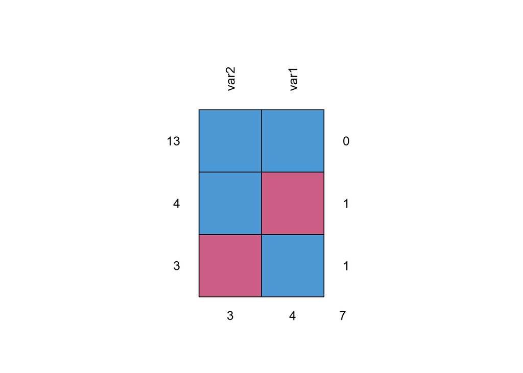

```
##
## Информация об импутации:
## Class: mids
## Number of multiple imputations:  5
## Imputation methods:
##  var1  var2
## "pmm" "pmm"
## PredictorMatrix:
##      var1 var2
## var1    0    1
## var2    1    0
##
## Датасет после заполнения пропусков (MICE - PMM):
##           var1     var2
## 1  -0.56047565 3.932176
## 2  -0.55584113 4.782025
## 3   1.55870831 3.973996
## 4   0.07050839 5.426464
## 5   0.49785048 4.374961
## 6   1.71506499 3.313307
## 7   0.11068272 5.837787
## 8  -1.26506123 5.688640
## 9  -0.68685285 3.861863
## 10 -0.55584113 6.253815
## 11  1.22408180 5.426464
## 12  0.35981383 4.704929
## 13  0.40077145 5.895126
## 14  0.11068272 5.878133
## 15 -0.55584113 5.821581
## 16  1.78691314 5.688640
## 17  0.49785048 5.553918
## 18 -1.96661716 4.938088
## 19  0.70135590 5.426464
## 20 -0.47279141 4.619529
```

```r
cat("\nСтатистика после заполнения:\n")
```

```
##
## Статистика после заполнения:
```

```r
summary(dataset_complete)
```

```
##       var1              var2
##  Min.   :-1.9666   Min.   :3.313
##  1st Qu.:-0.5558   1st Qu.:4.558
##  Median : 0.1107   Median :5.426
##  Mean   : 0.1207   Mean   :5.070
##  3rd Qu.: 0.5487   3rd Qu.:5.722
##  Max.   : 1.7869   Max.   :6.254
```

```r
# Проверяем отсутствие NA
cat("\nКоличество NA после импутации:\n")
```

```
##
## Количество NA после импутации:
```

```r
print(colSums(is.na(dataset_complete)))
```

```
## var1 var2
##    0    0
```

```r
# Сравнение средних
cat("\n Сравнение статистик до и после импутации \n")
```

```
##
##  Сравнение статистик до и после импутации
```

```r
comparison <- data.frame(
  Показатель = c("Среднее var1", "Медиана var1", "Среднее var2", "Медиана var2"),
  До_импутации = c(
    round(mean(dataset$var1, na.rm = TRUE), 4),
    round(median(dataset$var1, na.rm = TRUE), 4),
    round(mean(dataset$var2, na.rm = TRUE), 4),
    round(median(dataset$var2, na.rm = TRUE), 4)
  ),
  После_импутации = c(
    round(mean(dataset_complete$var1), 4),
    round(median(dataset_complete$var1), 4),
    round(mean(dataset_complete$var2), 4),
    round(median(dataset_complete$var2), 4)
  )
)
print(comparison)
```

```
##     Показатель До_импутации После_импутации
## 1 Среднее var1       0.1824          0.1207
## 2 Медиана var1       0.2352          0.1107
## 3 Среднее var2       4.9915          5.0699
## 4 Медиана var2       4.9381          5.4265
```